# Data Programming in Python | BAIS:6040

# Homework 6. Text Processing and Visualization

10 questions, 5 points in total

## Instructions

- Fill in the Python statements needed to complete all the questions below.
- Program everything inside this notebook.
- Use only one cell per question.
- Each code cell must be run with no errors.
- Do not contain any unnecessary code in your answer. (Only the final outcome will be regarded as your answer.)
- If the question requests that you store information in a certain variable, use the specific variables name (case sensitive).
- All problems must be solved in a programmable way.
- When you are done, make sure to save your notebook and then click Restart & Run All before subimission to create a clean version.

## Questions

For questions 1 to 5, you have a dataframe `dft` with only one column `tweet` as follows:

```python
# Do not make any change to this cell. Just run this cell.

texts = [
 'French President Emmanuel Macron announces a curfew for Paris and other cities starting Saturday to curb the spread of Covid-19.',
 'State police are investigating the incident in which Pennsylvania second lady Gisele Barreto Fetterman filmed a woman calling her the n-word outside a Braddock grocery store.',
 'The police officer who fatally shot a knife-wielding man in Pennsylvania last month was justified in opening fire and will not face criminal charges, the Lancaster District Attorney says.',
 'Patricia and Mark McCloskey, the St. Louis homeowners who pointed guns at protesters, plead not guilty to weapons and evidence tampering charges.',
 'Idaho college investigates reports of students intentionally contracting Covid-19 to sell their plasma.',
 'Italy records its highest daily coronavirus case increase since the pandemic began.',
 'New York state will withhold funding to local governments not enforcing closures in Covid-19 cluster areas, Gov. Andrew Cuomo says.',
 "Supreme Court nominee Amy Coney Barrett says she's never spoken in favor of the Affordable Care Act",
 'Supreme Court nominee Amy Coney Barrett said that "no one is above the law," but would not say one way or another if a president has the right to pardon him or herself.',
 "The Manhattan District Attorney's Office files a misdemeanor charge against the White woman who called police on a Black man birdwatching in Central Park in May, revealing that she had made a second 911 call about the encounter.",
 "Sen. Diane Feinstein, the top Democrat on the Senate Judiciary Committee, has announced a set of outside witnesses who will appear before the committee on the final day of Amy Coney Barrett's confirmation hearing.",
 "Senators get a second chance to question Trump's Supreme Court pick Amy Coney Barrett after an 11-hour session where she sidestepped saying how she'd rule on key issues.",
 'Biden and Trump will participate in competing, televised town halls on the night they were originally scheduled to debate.',
 "The Labor Department has announced that Secretary Eugene Scalia's wife, Trish, has tested positive for coronavirus.",
 'Conchata Ferrell, a beloved longtime character actress whose vast list of credits included roles in TV series like "Two and a Half Men" and films like "Edward Scissorhands" and "Erin Brockovich," has died. She was 77.',
 'The Justice Department is suing Stephanie Winston Wolkoff, an ex-friend and former adviser to first lady Melania Trump, claiming she breached a confidentiality agreement by publishing a tell-all book.',
 'At least 10 people have died in protests that started last week over police brutality in Nigeria, the human rights group Amnesty International says.',
 "Health officials in Nashville, Tennessee, are investigating an outdoor religious concert that they say took place downtown without a permit on Sunday and drew large crowds of people who weren't wearing masks.",
 'The New York Philharmonic has announced that it is canceling its entire concert season for the first time in its 178-year history.',
 "The Supreme Court has granted the Trump administration's request to halt the census count while an appeal plays out, a win for the administration.",
 'An elderly Dutch woman has become the first known person to die from catching Covid-19 twice, according to experts, raising serious questions about how long immunity and antibodies can last.',
 'World No. 1 ranked golfer Dustin Johnson has tested positive for Covid-19, the PGA Tour says in a statement.',
 'Drugmaker Eli Lilly says it is pausing its trial of a combination antibody treatment for coronavirus due to safety reasons .',
 'Apple unveils iPhones with 5G connectivity and a new model that is smaller, thinner and has double the pixels of the iPhone 11.',
 "A computer outage caused by a cut fiber cable has taken down Virginia's voter registration system on the final day to register before the election.",
 'The group charged with plotting to kidnap Michigan Gov. Whitmer also discussed targeting Virginia Gov. Northam, an FBI agent says.',
 'Soccer superstar Cristiano Ronaldo has tested positive for coronavirus, Portuguese sports officials say.',
 "Live: Senators get the chance to question Trump's Supreme Court pick Amy Coney Barrett on a critical day for her nomination.",
 'Johnson & Johnson pauses the advanced clinical trial of its experimental Covid-19 vaccine due to an unexplained illness in a volunteer.',
 'Trump has tested negative for Covid-19 on consecutive days, White House physician Sean Conley says as the President heads to a crowded Florida rally.'
 'Disney announced a major reorganization of its media and entertainment business on Monday to "further accelerate" its streaming strategy.',
 'Roberta McCain, mother of the late Sen. John McCain, died Monday at the age of 108, Cindy McCain says.',
 'Covid-19 cases are rising in North Dakota, and hospitals are struggling to meet the demand for care, with fewer than 20 beds available across the state.',
 'Microsoft says it has taken down the servers behind Trickbot, an enormous malware network that it says could have indirectly affected election infrastructure',
 'Two American economists share the 2020 Nobel Prize in Economics for their work in the theory of auction markets.',
 'The Los Angeles Lakers are NBA champions, defeating the Miami Heat 106-93 in Game 6 of the NBA Finals.',
 'A Louisiana man died in the aftermath of Hurricane Delta, and two people in Georgia were injured Saturday during tornadoes spawned by the storm.',
 "Rafael Nadal beat Novak Djokovic to win his 13th French Open and 20th grand slam title, tying Roger Federer for the all-time men's lead in majors.",
 'A second national lockdown is a "possibility" in England, a leading expert and government adviser says.',
 'White House economic adviser Larry Kudlow says Mnuchin "may" go above $2.2 trillion in stimulus offer.',
 'The NFL postpones Broncos-Patriots game after the Patriots reported a positive Covid-19 test.',
 'About 500,000 households and businesses are without electricity after Hurricane Delta.',
 'One person died and another was taken into custody after a shooting near dueling protests in Denver, police say.'
 'Trump is cleared to return to a public schedule, according to a new memo from his doctor. But it does not say Trump has tested negative for coronavirus.'
 "A federal appeals court has granted a temporary administrative stay, allowing Texas Gov. Greg Abbott's directive for one location per county for ballot drop boxes to remain in place for now.",
 "Nepal has recorded 5,008 new coronavirus cases, the country's highest daily increase in new infections, according to its health ministry.",
 'France has recorded 26,896 new cases of coronavirus, setting a new record for daily reported infections since the start of the pandemic, according to the French Health Ministry.',
 "President Trump's $1.8 trillion stimulus proposal faces opposition from Democrats and Republicans, all but guaranteeing an economic relief bill won't pass before Election Day.",
 'Canadian Prime Minister Justin Trudeau and President Trump discussed ongoing efforts by their countries to manage the Covid-19 pandemic during a phone call today.',
 "North Korea unveils what analysts believe to be one of the world's largest ballistic missiles.",
 "Chris Christie says he's been released from the hospital. He checked himself in a week ago after testing positive for Covid-19.",
 'The US records its third consecutive day of more than 50,000 Covid-19 cases. The last time America reached this milestone was in mid-August.',
 'Disney announced a major reorganization of its media and entertainment business on Monday to "further accelerate" its streaming strategy.'
]

import pandas as pd
pd.set_option('display.max_colwidth', 280)

dft = pd.DataFrame(data=texts, columns=["tweet"])
dft
```

|  | tweet |
| --- | --- |
| 0 | French President Emmanuel Macron announces a curfew for Paris and other cities starting Saturday to curb the spread of Covid-19. |
| 1 | State police are investigating the incident in which Pennsylvania second lady Gisele Barreto Fetterman filmed a woman calling her the n-word outside a Braddock grocery store. |
| 2 | The police officer who fatally shot a knife-wielding man in Pennsylvania last month was justified in opening fire and will not face criminal charges, the Lancaster District Attorney says. |
| 3 | Patricia and Mark McCloskey, the St. Louis homeowners who pointed guns at protesters, plead not guilty to weapons and evidence tampering charges. |
| 4 | Idaho college investigates reports of students intentionally contracting Covid-19 to sell their plasma. |
| 5 | Italy records its highest daily coronavirus case increase since the pandemic began. |
| 6 | New York state will withhold funding to local governments not enforcing closures in Covid-19 cluster areas, Gov. Andrew Cuomo says. |
| 7 | Supreme Court nominee Amy Coney Barrett says she's never spoken in favor of the Affordable Care Act |
| 8 | Supreme Court nominee Amy Coney Barrett said that "no one is above the law," but would not say one way or another if a president has the right to pardon him or herself. |
| 9 | The Manhattan District Attorney's Office files a misdemeanor charge against the White woman who called police on a Black man birdwatching in Central Park in May, revealing that she had made a second 9… |
| 10 | Sen. Diane Feinstein, the top Democrat on the Senate Judiciary Committee, has announced a set of outside witnesses who will appear before the committee on the final day of Amy Coney Barrett's confirma… |
| 11 | Senators get a second chance to question Trump's Supreme Court pick Amy Coney Barrett after an 11-hour session where she sidestepped saying how she'd rule on key issues. |
| 12 | Biden and Trump will participate in competing, televised town halls on the night they were originally scheduled to debate. |
| 13 | The Labor Department has announced that Secretary Eugene Scalia's wife, Trish, has tested positive for coronavirus. |
| 14 | Conchata Ferrell, a beloved longtime character actress whose vast list of credits included roles in TV series like "Two and a Half Men" and films like "Edward Scissorhands" and "Erin Brockovich," has … |
| 15 | The Justice Department is suing Stephanie Winston Wolkoff, an ex-friend and former adviser to first lady Melania Trump, claiming she breached a confidentiality agreement by publishing a tell-all book. |
| 16 | At least 10 people have died in protests that started last week over police brutality in Nigeria, the human rights group Amnesty International says. |
| 17 | Health officials in Nashville, Tennessee, are investigating an outdoor religious concert that they say took place downtown without a permit on Sunday and drew large crowds of people who weren't wearin… |
| 18 | The New York Philharmonic has announced that it is canceling its entire concert season for the first time in its 178-year history. |
| 19 | The Supreme Court has granted the Trump administration's request to halt the census count while an appeal plays out, a win for the administration. |
| 20 | An elderly Dutch woman has become the first known person to die from catching Covid-19 twice, according to experts, raising serious questions about how long immunity and antibodies can last. |
| 21 | World No. 1 ranked golfer Dustin Johnson has tested positive for Covid-19, the PGA Tour says in a statement. |
| 22 | Drugmaker Eli Lilly says it is pausing its trial of a combination antibody treatment for coronavirus due to safety reasons . |
| 23 | Apple unveils iPhones with 5G connectivity and a new model that is smaller, thinner and has double the pixels of the iPhone 11. |
| 24 | A computer outage caused by a cut fiber cable has taken down Virginia's voter registration system on the final day to register before the election. |
| 25 | The group charged with plotting to kidnap Michigan Gov. Whitmer also discussed targeting Virginia Gov. Northam, an FBI agent says. |
| 26 | Soccer superstar Cristiano Ronaldo has tested positive for coronavirus, Portuguese sports officials say. |
| 27 | Live: Senators get the chance to question Trump's Supreme Court pick Amy Coney Barrett on a critical day for her nomination. |
| 28 | Johnson & Johnson pauses the advanced clinical trial of its experimental Covid-19 vaccine due to an unexplained illness in a volunteer. |
| 29 | Trump has tested negative for Covid-19 on consecutive days, White House physician Sean Conley says as the President heads to a crowded Florida rally.Disney announced a major reorganization of its medi… |
| 30 | Roberta McCain, mother of the late Sen. John McCain, died Monday at the age of 108, Cindy McCain says. |
| 31 | Covid-19 cases are rising in North Dakota, and hospitals are struggling to meet the demand for care, with fewer than 20 beds available across the state. |
| 32 | Microsoft says it has taken down the servers behind Trickbot, an enormous malware network that it says could have indirectly affected election infrastructure |
| 33 | Two American economists share the 2020 Nobel Prize in Economics for their work in the theory of auction markets. |
| 34 | The Los Angeles Lakers are NBA champions, defeating the Miami Heat 106-93 in Game 6 of the NBA Finals. |
| 35 | A Louisiana man died in the aftermath of Hurricane Delta, and two people in Georgia were injured Saturday during tornadoes spawned by the storm. |
| 36 | Rafael Nadal beat Novak Djokovic to win his 13th French Open and 20th grand slam title, tying Roger Federer for the all-time men's lead in majors. |
| 37 | A second national lockdown is a "possibility" in England, a leading expert and government adviser says. |
| 38 | White House economic adviser Larry Kudlow says Mnuchin "may" go above $2.2 trillion in stimulus offer. |
| 39 | The NFL postpones Broncos-Patriots game after the Patriots reported a positive Covid-19 test. |
| 40 | About 500,000 households and businesses are without electricity after Hurricane Delta. |
| 41 | One person died and another was taken into custody after a shooting near dueling protests in Denver, police say.Trump is cleared to return to a public schedule, according to a new memo from his doctor… |
| 42 | Nepal has recorded 5,008 new coronavirus cases, the country's highest daily increase in new infections, according to its health ministry. |
| 43 | France has recorded 26,896 new cases of coronavirus, setting a new record for daily reported infections since the start of the pandemic, according to the French Health Ministry. |
| 44 | President Trump's $1.8 trillion stimulus proposal faces opposition from Democrats and Republicans, all but guaranteeing an economic relief bill won't pass before Election Day. |
| 45 | Canadian Prime Minister Justin Trudeau and President Trump discussed ongoing efforts by their countries to manage the Covid-19 pandemic during a phone call today. |
| 46 | North Korea unveils what analysts believe to be one of the world's largest ballistic missiles. |
| 47 | Chris Christie says he's been released from the hospital. He checked himself in a week ago after testing positive for Covid-19. |
| 48 | The US records its third consecutive day of more than 50,000 Covid-19 cases. The last time America reached this milestone was in mid-August. |
| 49 | Disney announced a major reorganization of its media and entertainment business on Monday to "further accelerate" its streaming strategy. |

1. (0.5 pts) Add a new column `tweet_length` that contains the length of the `tweet` column.

```python
# Your answer here
dft["tweet_length"] = dft.tweet.apply(lambda x: len(x))
```

```python
# Check your answer here. (Do not make any change to this cell. Just run this cell.)
dft[["tweet", "tweet_length"]]
```

|  | tweet | tweet_length |
| --- | --- | --- |
| 0 | French President Emmanuel Macron announces a curfew for Paris and other cities starting Saturday to curb the spread of Covid-19. | 128 |
| 1 | State police are investigating the incident in which Pennsylvania second lady Gisele Barreto Fetterman filmed a woman calling her the n-word outside a Braddock grocery store. | 174 |
| 2 | The police officer who fatally shot a knife-wielding man in Pennsylvania last month was justified in opening fire and will not face criminal charges, the Lancaster District Attorney says. | 187 |
| 3 | Patricia and Mark McCloskey, the St. Louis homeowners who pointed guns at protesters, plead not guilty to weapons and evidence tampering charges. | 145 |
| 4 | Idaho college investigates reports of students intentionally contracting Covid-19 to sell their plasma. | 103 |
| 5 | Italy records its highest daily coronavirus case increase since the pandemic began. | 83 |
| 6 | New York state will withhold funding to local governments not enforcing closures in Covid-19 cluster areas, Gov. Andrew Cuomo says. | 131 |
| 7 | Supreme Court nominee Amy Coney Barrett says she's never spoken in favor of the Affordable Care Act | 99 |
| 8 | Supreme Court nominee Amy Coney Barrett said that "no one is above the law," but would not say one way or another if a president has the right to pardon him or herself. | 168 |
| 9 | The Manhattan District Attorney's Office files a misdemeanor charge against the White woman who called police on a Black man birdwatching in Central Park in May, revealing that she had made a second 9… | 228 |
| 10 | Sen. Diane Feinstein, the top Democrat on the Senate Judiciary Committee, has announced a set of outside witnesses who will appear before the committee on the final day of Amy Coney Barrett's confirma… | 213 |
| 11 | Senators get a second chance to question Trump's Supreme Court pick Amy Coney Barrett after an 11-hour session where she sidestepped saying how she'd rule on key issues. | 169 |
| 12 | Biden and Trump will participate in competing, televised town halls on the night they were originally scheduled to debate. | 122 |
| 13 | The Labor Department has announced that Secretary Eugene Scalia's wife, Trish, has tested positive for coronavirus. | 115 |
| 14 | Conchata Ferrell, a beloved longtime character actress whose vast list of credits included roles in TV series like "Two and a Half Men" and films like "Edward Scissorhands" and "Erin Brockovich," has … | 217 |
| 15 | The Justice Department is suing Stephanie Winston Wolkoff, an ex-friend and former adviser to first lady Melania Trump, claiming she breached a confidentiality agreement by publishing a tell-all book. | 200 |
| 16 | At least 10 people have died in protests that started last week over police brutality in Nigeria, the human rights group Amnesty International says. | 148 |
| 17 | Health officials in Nashville, Tennessee, are investigating an outdoor religious concert that they say took place downtown without a permit on Sunday and drew large crowds of people who weren't wearin… | 208 |
| 18 | The New York Philharmonic has announced that it is canceling its entire concert season for the first time in its 178-year history. | 130 |
| 19 | The Supreme Court has granted the Trump administration's request to halt the census count while an appeal plays out, a win for the administration. | 146 |
| 20 | An elderly Dutch woman has become the first known person to die from catching Covid-19 twice, according to experts, raising serious questions about how long immunity and antibodies can last. | 190 |
| 21 | World No. 1 ranked golfer Dustin Johnson has tested positive for Covid-19, the PGA Tour says in a statement. | 108 |
| 22 | Drugmaker Eli Lilly says it is pausing its trial of a combination antibody treatment for coronavirus due to safety reasons . | 124 |
| 23 | Apple unveils iPhones with 5G connectivity and a new model that is smaller, thinner and has double the pixels of the iPhone 11. | 127 |
| 24 | A computer outage caused by a cut fiber cable has taken down Virginia's voter registration system on the final day to register before the election. | 147 |
| 25 | The group charged with plotting to kidnap Michigan Gov. Whitmer also discussed targeting Virginia Gov. Northam, an FBI agent says. | 130 |
| 26 | Soccer superstar Cristiano Ronaldo has tested positive for coronavirus, Portuguese sports officials say. | 104 |
| 27 | Live: Senators get the chance to question Trump's Supreme Court pick Amy Coney Barrett on a critical day for her nomination. | 124 |
| 28 | Johnson & Johnson pauses the advanced clinical trial of its experimental Covid-19 vaccine due to an unexplained illness in a volunteer. | 135 |
| 29 | Trump has tested negative for Covid-19 on consecutive days, White House physician Sean Conley says as the President heads to a crowded Florida rally.Disney announced a major reorganization of its medi… | 286 |
| 30 | Roberta McCain, mother of the late Sen. John McCain, died Monday at the age of 108, Cindy McCain says. | 102 |
| 31 | Covid-19 cases are rising in North Dakota, and hospitals are struggling to meet the demand for care, with fewer than 20 beds available across the state. | 152 |
| 32 | Microsoft says it has taken down the servers behind Trickbot, an enormous malware network that it says could have indirectly affected election infrastructure | 157 |
| 33 | Two American economists share the 2020 Nobel Prize in Economics for their work in the theory of auction markets. | 112 |
| 34 | The Los Angeles Lakers are NBA champions, defeating the Miami Heat 106-93 in Game 6 of the NBA Finals. | 102 |
| 35 | A Louisiana man died in the aftermath of Hurricane Delta, and two people in Georgia were injured Saturday during tornadoes spawned by the storm. | 144 |
| 36 | Rafael Nadal beat Novak Djokovic to win his 13th French Open and 20th grand slam title, tying Roger Federer for the all-time men's lead in majors. | 146 |
| 37 | A second national lockdown is a "possibility" in England, a leading expert and government adviser says. | 103 |
| 38 | White House economic adviser Larry Kudlow says Mnuchin "may" go above $2.2 trillion in stimulus offer. | 102 |
| 39 | The NFL postpones Broncos-Patriots game after the Patriots reported a positive Covid-19 test. | 93 |
| 40 | About 500,000 households and businesses are without electricity after Hurricane Delta. | 86 |
| 41 | One person died and another was taken into custody after a shooting near dueling protests in Denver, police say.Trump is cleared to return to a public schedule, according to a new memo from his doctor… | 454 |
| 42 | Nepal has recorded 5,008 new coronavirus cases, the country's highest daily increase in new infections, according to its health ministry. | 137 |
| 43 | France has recorded 26,896 new cases of coronavirus, setting a new record for daily reported infections since the start of the pandemic, according to the French Health Ministry. | 177 |
| 44 | President Trump's $1.8 trillion stimulus proposal faces opposition from Democrats and Republicans, all but guaranteeing an economic relief bill won't pass before Election Day. | 175 |
| 45 | Canadian Prime Minister Justin Trudeau and President Trump discussed ongoing efforts by their countries to manage the Covid-19 pandemic during a phone call today. | 162 |
| 46 | North Korea unveils what analysts believe to be one of the world's largest ballistic missiles. | 94 |
| 47 | Chris Christie says he's been released from the hospital. He checked himself in a week ago after testing positive for Covid-19. | 127 |
| 48 | The US records its third consecutive day of more than 50,000 Covid-19 cases. The last time America reached this milestone was in mid-August. | 140 |
| 49 | Disney announced a major reorganization of its media and entertainment business on Monday to "further accelerate" its streaming strategy. | 137 |

2. (0.5 pts) Add two new columns `words`, which contains the words identified from the `tweet` column, and `tagged_words`, which contains the part-of-speech tag information identified from the `words` column. Import any module necessary.

```python
# Your answer here
import nltk
dft["words"] = dft.tweet.apply(lambda x: nltk.word_tokenize(x))
dft["tagged_words"] = dft.words.apply(lambda x: nltk.pos_tag(x))
```

```python
# Check your answer here. (Do not make any change to this cell. Just run this cell.)
dft[["tweet", "words", "tagged_words"]]
```

|  | tweet | words | tagged_words |
| --- | --- | --- | --- |
| 0 | French President Emmanuel Macron announces a curfew for Paris and other cities starting Saturday to curb the spread of Covid-19. | [French, President, Emmanuel, Macron, announces, a, curfew, for, Paris, and, other, cities, starting, Saturday, to, curb, the, spread, of, Covid-19, .] | [(French, JJ), (President, NNP), (Emmanuel, NNP), (Macron, NNP), (announces, VBZ), (a, DT), (curfew, NN), (for, IN), (Paris, NNP), (and, CC), (other, JJ), (cities, NNS), (starting, VBG), (Saturday, NN… |
| 1 | State police are investigating the incident in which Pennsylvania second lady Gisele Barreto Fetterman filmed a woman calling her the n-word outside a Braddock grocery store. | [State, police, are, investigating, the, incident, in, which, Pennsylvania, second, lady, Gisele, Barreto, Fetterman, filmed, a, woman, calling, her, the, n-word, outside, a, Braddock, grocery, store,… | [(State, NNP), (police, NNS), (are, VBP), (investigating, VBG), (the, DT), (incident, NN), (in, IN), (which, WDT), (Pennsylvania, NNP), (second, VBD), (lady, JJ), (Gisele, NNP), (Barreto, NNP), (Fette… |
| 2 | The police officer who fatally shot a knife-wielding man in Pennsylvania last month was justified in opening fire and will not face criminal charges, the Lancaster District Attorney says. | [The, police, officer, who, fatally, shot, a, knife-wielding, man, in, Pennsylvania, last, month, was, justified, in, opening, fire, and, will, not, face, criminal, charges, ,, the, Lancaster, Distric… | [(The, DT), (police, NN), (officer, NN), (who, WP), (fatally, RB), (shot, VBP), (a, DT), (knife-wielding, JJ), (man, NN), (in, IN), (Pennsylvania, NNP), (last, JJ), (month, NN), (was, VBD), (justified… |
| 3 | Patricia and Mark McCloskey, the St. Louis homeowners who pointed guns at protesters, plead not guilty to weapons and evidence tampering charges. | [Patricia, and, Mark, McCloskey, ,, the, St., Louis, homeowners, who, pointed, guns, at, protesters, ,, plead, not, guilty, to, weapons, and, evidence, tampering, charges, .] | [(Patricia, NNP), (and, CC), (Mark, NNP), (McCloskey, NNP), (,, ,), (the, DT), (St., NNP), (Louis, NNP), (homeowners, NNS), (who, WP), (pointed, VBD), (guns, NNS), (at, IN), (protesters, NNS), (,, ,),… |
| 4 | Idaho college investigates reports of students intentionally contracting Covid-19 to sell their plasma. | [Idaho, college, investigates, reports, of, students, intentionally, contracting, Covid-19, to, sell, their, plasma, .] | [(Idaho, NNP), (college, NN), (investigates, NNS), (reports, NNS), (of, IN), (students, NNS), (intentionally, RB), (contracting, VBG), (Covid-19, NNP), (to, TO), (sell, VB), (their, PRP$), (plasma, NN… |
| 5 | Italy records its highest daily coronavirus case increase since the pandemic began. | [Italy, records, its, highest, daily, coronavirus, case, increase, since, the, pandemic, began, .] | [(Italy, NNP), (records, VBZ), (its, PRP$), (highest, JJS), (daily, JJ), (coronavirus, NN), (case, NN), (increase, NN), (since, IN), (the, DT), (pandemic, JJ), (began, VBD), (., .)] |
| 6 | New York state will withhold funding to local governments not enforcing closures in Covid-19 cluster areas, Gov. Andrew Cuomo says. | [New, York, state, will, withhold, funding, to, local, governments, not, enforcing, closures, in, Covid-19, cluster, areas, ,, Gov, ., Andrew, Cuomo, says, .] | [(New, NNP), (York, NNP), (state, NN), (will, MD), (withhold, VB), (funding, NN), (to, TO), (local, JJ), (governments, NNS), (not, RB), (enforcing, VBG), (closures, NNS), (in, IN), (Covid-19, NNP), (c… |
| 7 | Supreme Court nominee Amy Coney Barrett says she's never spoken in favor of the Affordable Care Act | [Supreme, Court, nominee, Amy, Coney, Barrett, says, she, 's, never, spoken, in, favor, of, the, Affordable, Care, Act] | [(Supreme, NNP), (Court, NNP), (nominee, VBD), (Amy, NNP), (Coney, NNP), (Barrett, NNP), (says, VBZ), (she, PRP), ('s, VBZ), (never, RB), (spoken, VBN), (in, IN), (favor, NN), (of, IN), (the, DT), (Af… |
| 8 | Supreme Court nominee Amy Coney Barrett said that "no one is above the law," but would not say one way or another if a president has the right to pardon him or herself. | [Supreme, Court, nominee, Amy, Coney, Barrett, said, that, ``, no, one, is, above, the, law, ,, '', but, would, not, say, one, way, or, another, if, a, president, has, the, right, to, pardon, him, or,… | [(Supreme, NNP), (Court, NNP), (nominee, VBD), (Amy, NNP), (Coney, NNP), (Barrett, NNP), (said, VBD), (that, IN), (``, ``), (no, DT), (one, NN), (is, VBZ), (above, IN), (the, DT), (law, NN), (,, ,), (… |
| 9 | The Manhattan District Attorney's Office files a misdemeanor charge against the White woman who called police on a Black man birdwatching in Central Park in May, revealing that she had made a second 9… | [The, Manhattan, District, Attorney, 's, Office, files, a, misdemeanor, charge, against, the, White, woman, who, called, police, on, a, Black, man, birdwatching, in, Central, Park, in, May, ,, reveali… | [(The, DT), (Manhattan, NNP), (District, NNP), (Attorney, NNP), ('s, POS), (Office, NN), (files, VBZ), (a, DT), (misdemeanor, JJ), (charge, NN), (against, IN), (the, DT), (White, NNP), (woman, NN), (w… |
| 10 | Sen. Diane Feinstein, the top Democrat on the Senate Judiciary Committee, has announced a set of outside witnesses who will appear before the committee on the final day of Amy Coney Barrett's confirma… | [Sen., Diane, Feinstein, ,, the, top, Democrat, on, the, Senate, Judiciary, Committee, ,, has, announced, a, set, of, outside, witnesses, who, will, appear, before, the, committee, on, the, final, day… | [(Sen., NNP), (Diane, NNP), (Feinstein, NNP), (,, ,), (the, DT), (top, JJ), (Democrat, NNP), (on, IN), (the, DT), (Senate, NNP), (Judiciary, NNP), (Committee, NNP), (,, ,), (has, VBZ), (announced, VBN… |
| 11 | Senators get a second chance to question Trump's Supreme Court pick Amy Coney Barrett after an 11-hour session where she sidestepped saying how she'd rule on key issues. | [Senators, get, a, second, chance, to, question, Trump, 's, Supreme, Court, pick, Amy, Coney, Barrett, after, an, 11-hour, session, where, she, sidestepped, saying, how, she, 'd, rule, on, key, issues… | [(Senators, NNS), (get, VBP), (a, DT), (second, JJ), (chance, NN), (to, TO), (question, VB), (Trump, NNP), ('s, POS), (Supreme, NNP), (Court, NNP), (pick, VBP), (Amy, NNP), (Coney, NNP), (Barrett, NNP… |
| 12 | Biden and Trump will participate in competing, televised town halls on the night they were originally scheduled to debate. | [Biden, and, Trump, will, participate, in, competing, ,, televised, town, halls, on, the, night, they, were, originally, scheduled, to, debate, .] | [(Biden, NNP), (and, CC), (Trump, NNP), (will, MD), (participate, VB), (in, IN), (competing, VBG), (,, ,), (televised, VBN), (town, NN), (halls, NNS), (on, IN), (the, DT), (night, NN), (they, PRP), (w… |
| 13 | The Labor Department has announced that Secretary Eugene Scalia's wife, Trish, has tested positive for coronavirus. | [The, Labor, Department, has, announced, that, Secretary, Eugene, Scalia, 's, wife, ,, Trish, ,, has, tested, positive, for, coronavirus, .] | [(The, DT), (Labor, NNP), (Department, NNP), (has, VBZ), (announced, VBN), (that, IN), (Secretary, NNP), (Eugene, NNP), (Scalia, NNP), ('s, POS), (wife, NN), (,, ,), (Trish, NNP), (,, ,), (has, VBZ), … |
| 14 | Conchata Ferrell, a beloved longtime character actress whose vast list of credits included roles in TV series like "Two and a Half Men" and films like "Edward Scissorhands" and "Erin Brockovich," has … | [Conchata, Ferrell, ,, a, beloved, longtime, character, actress, whose, vast, list, of, credits, included, roles, in, TV, series, like, ``, Two, and, a, Half, Men, '', and, films, like, ``, Edward, Sc… | [(Conchata, NNP), (Ferrell, NNP), (,, ,), (a, DT), (beloved, JJ), (longtime, JJ), (character, NN), (actress, NN), (whose, WP$), (vast, JJ), (list, NN), (of, IN), (credits, NNS), (included, VBN), (role… |
| 15 | The Justice Department is suing Stephanie Winston Wolkoff, an ex-friend and former adviser to first lady Melania Trump, claiming she breached a confidentiality agreement by publishing a tell-all book. | [The, Justice, Department, is, suing, Stephanie, Winston, Wolkoff, ,, an, ex-friend, and, former, adviser, to, first, lady, Melania, Trump, ,, claiming, she, breached, a, confidentiality, agreement, b… | [(The, DT), (Justice, NNP), (Department, NNP), (is, VBZ), (suing, VBG), (Stephanie, NNP), (Winston, NNP), (Wolkoff, NNP), (,, ,), (an, DT), (ex-friend, JJ), (and, CC), (former, JJ), (adviser, NN), (to… |
| 16 | At least 10 people have died in protests that started last week over police brutality in Nigeria, the human rights group Amnesty International says. | [At, least, 10, people, have, died, in, protests, that, started, last, week, over, police, brutality, in, Nigeria, ,, the, human, rights, group, Amnesty, International, says, .] | [(At, IN), (least, JJS), (10, CD), (people, NNS), (have, VBP), (died, VBN), (in, IN), (protests, NNS), (that, WDT), (started, VBD), (last, JJ), (week, NN), (over, IN), (police, JJ), (brutality, NN), (… |
| 17 | Health officials in Nashville, Tennessee, are investigating an outdoor religious concert that they say took place downtown without a permit on Sunday and drew large crowds of people who weren't wearin… | [Health, officials, in, Nashville, ,, Tennessee, ,, are, investigating, an, outdoor, religious, concert, that, they, say, took, place, downtown, without, a, permit, on, Sunday, and, drew, large, crowd… | [(Health, NNP), (officials, NNS), (in, IN), (Nashville, NNP), (,, ,), (Tennessee, NNP), (,, ,), (are, VBP), (investigating, VBG), (an, DT), (outdoor, JJ), (religious, JJ), (concert, NN), (that, IN), (… |
| 18 | The New York Philharmonic has announced that it is canceling its entire concert season for the first time in its 178-year history. | [The, New, York, Philharmonic, has, announced, that, it, is, canceling, its, entire, concert, season, for, the, first, time, in, its, 178-year, history, .] | [(The, DT), (New, NNP), (York, NNP), (Philharmonic, NNP), (has, VBZ), (announced, VBN), (that, IN), (it, PRP), (is, VBZ), (canceling, VBG), (its, PRP$), (entire, JJ), (concert, NN), (season, NN), (for… |
| 19 | The Supreme Court has granted the Trump administration's request to halt the census count while an appeal plays out, a win for the administration. | [The, Supreme, Court, has, granted, the, Trump, administration, 's, request, to, halt, the, census, count, while, an, appeal, plays, out, ,, a, win, for, the, administration, .] | [(The, DT), (Supreme, NNP), (Court, NNP), (has, VBZ), (granted, VBN), (the, DT), (Trump, NNP), (administration, NN), ('s, POS), (request, NN), (to, TO), (halt, VB), (the, DT), (census, NN), (count, NN… |
| 20 | An elderly Dutch woman has become the first known person to die from catching Covid-19 twice, according to experts, raising serious questions about how long immunity and antibodies can last. | [An, elderly, Dutch, woman, has, become, the, first, known, person, to, die, from, catching, Covid-19, twice, ,, according, to, experts, ,, raising, serious, questions, about, how, long, immunity, and… | [(An, DT), (elderly, JJ), (Dutch, NNP), (woman, NN), (has, VBZ), (become, VBN), (the, DT), (first, JJ), (known, VBN), (person, NN), (to, TO), (die, VB), (from, IN), (catching, VBG), (Covid-19, NNP), (… |
| 21 | World No. 1 ranked golfer Dustin Johnson has tested positive for Covid-19, the PGA Tour says in a statement. | [World, No, ., 1, ranked, golfer, Dustin, Johnson, has, tested, positive, for, Covid-19, ,, the, PGA, Tour, says, in, a, statement, .] | [(World, NNP), (No, NNP), (., .), (1, CD), (ranked, VBD), (golfer, NN), (Dustin, NNP), (Johnson, NNP), (has, VBZ), (tested, VBN), (positive, JJ), (for, IN), (Covid-19, NNP), (,, ,), (the, DT), (PGA, N… |
| 22 | Drugmaker Eli Lilly says it is pausing its trial of a combination antibody treatment for coronavirus due to safety reasons . | [Drugmaker, Eli, Lilly, says, it, is, pausing, its, trial, of, a, combination, antibody, treatment, for, coronavirus, due, to, safety, reasons, .] | [(Drugmaker, NNP), (Eli, NNP), (Lilly, NNP), (says, VBZ), (it, PRP), (is, VBZ), (pausing, VBG), (its, PRP$), (trial, NN), (of, IN), (a, DT), (combination, NN), (antibody, NN), (treatment, NN), (for, I… |
| 23 | Apple unveils iPhones with 5G connectivity and a new model that is smaller, thinner and has double the pixels of the iPhone 11. | [Apple, unveils, iPhones, with, 5G, connectivity, and, a, new, model, that, is, smaller, ,, thinner, and, has, double, the, pixels, of, the, iPhone, 11, .] | [(Apple, NNP), (unveils, JJ), (iPhones, NNS), (with, IN), (5G, CD), (connectivity, NN), (and, CC), (a, DT), (new, JJ), (model, NN), (that, WDT), (is, VBZ), (smaller, JJR), (,, ,), (thinner, NN), (and,… |
| 24 | A computer outage caused by a cut fiber cable has taken down Virginia's voter registration system on the final day to register before the election. | [A, computer, outage, caused, by, a, cut, fiber, cable, has, taken, down, Virginia, 's, voter, registration, system, on, the, final, day, to, register, before, the, election, .] | [(A, DT), (computer, NN), (outage, NN), (caused, VBN), (by, IN), (a, DT), (cut, NN), (fiber, NN), (cable, NN), (has, VBZ), (taken, VBN), (down, RP), (Virginia, NNP), ('s, POS), (voter, NN), (registrat… |
| 25 | The group charged with plotting to kidnap Michigan Gov. Whitmer also discussed targeting Virginia Gov. Northam, an FBI agent says. | [The, group, charged, with, plotting, to, kidnap, Michigan, Gov, ., Whitmer, also, discussed, targeting, Virginia, Gov, ., Northam, ,, an, FBI, agent, says, .] | [(The, DT), (group, NN), (charged, VBD), (with, IN), (plotting, VBG), (to, TO), (kidnap, VB), (Michigan, NNP), (Gov, NNP), (., .), (Whitmer, NNP), (also, RB), (discussed, VBD), (targeting, VBG), (Virg… |
| 26 | Soccer superstar Cristiano Ronaldo has tested positive for coronavirus, Portuguese sports officials say. | [Soccer, superstar, Cristiano, Ronaldo, has, tested, positive, for, coronavirus, ,, Portuguese, sports, officials, say, .] | [(Soccer, NNP), (superstar, NN), (Cristiano, NNP), (Ronaldo, NNP), (has, VBZ), (tested, VBN), (positive, JJ), (for, IN), (coronavirus, NN), (,, ,), (Portuguese, JJ), (sports, NNS), (officials, NNS), (… |
| 27 | Live: Senators get the chance to question Trump's Supreme Court pick Amy Coney Barrett on a critical day for her nomination. | [Live, :, Senators, get, the, chance, to, question, Trump, 's, Supreme, Court, pick, Amy, Coney, Barrett, on, a, critical, day, for, her, nomination, .] | [(Live, JJ), (:, :), (Senators, NNS), (get, VBP), (the, DT), (chance, NN), (to, TO), (question, VB), (Trump, NNP), ('s, POS), (Supreme, NNP), (Court, NNP), (pick, VBP), (Amy, NNP), (Coney, NNP), (Barr… |
| 28 | Johnson & Johnson pauses the advanced clinical trial of its experimental Covid-19 vaccine due to an unexplained illness in a volunteer. | [Johnson, &, Johnson, pauses, the, advanced, clinical, trial, of, its, experimental, Covid-19, vaccine, due, to, an, unexplained, illness, in, a, volunteer, .] | [(Johnson, NNP), (&, CC), (Johnson, NNP), (pauses, VBZ), (the, DT), (advanced, JJ), (clinical, JJ), (trial, NN), (of, IN), (its, PRP$), (experimental, JJ), (Covid-19, JJ), (vaccine, NN), (due, JJ), (t… |
| 29 | Trump has tested negative for Covid-19 on consecutive days, White House physician Sean Conley says as the President heads to a crowded Florida rally.Disney announced a major reorganization of its medi… | [Trump, has, tested, negative, for, Covid-19, on, consecutive, days, ,, White, House, physician, Sean, Conley, says, as, the, President, heads, to, a, crowded, Florida, rally.Disney, announced, a, maj… | [(Trump, NNP), (has, VBZ), (tested, VBN), (negative, JJ), (for, IN), (Covid-19, NNP), (on, IN), (consecutive, JJ), (days, NNS), (,, ,), (White, NNP), (House, NNP), (physician, JJ), (Sean, NNP), (Conle… |
| 30 | Roberta McCain, mother of the late Sen. John McCain, died Monday at the age of 108, Cindy McCain says. | [Roberta, McCain, ,, mother, of, the, late, Sen., John, McCain, ,, died, Monday, at, the, age, of, 108, ,, Cindy, McCain, says, .] | [(Roberta, NNP), (McCain, NNP), (,, ,), (mother, NN), (of, IN), (the, DT), (late, JJ), (Sen., NNP), (John, NNP), (McCain, NNP), (,, ,), (died, VBD), (Monday, NNP), (at, IN), (the, DT), (age, NN), (of,… |
| 31 | Covid-19 cases are rising in North Dakota, and hospitals are struggling to meet the demand for care, with fewer than 20 beds available across the state. | [Covid-19, cases, are, rising, in, North, Dakota, ,, and, hospitals, are, struggling, to, meet, the, demand, for, care, ,, with, fewer, than, 20, beds, available, across, the, state, .] | [(Covid-19, JJ), (cases, NNS), (are, VBP), (rising, VBG), (in, IN), (North, NNP), (Dakota, NNP), (,, ,), (and, CC), (hospitals, NNS), (are, VBP), (struggling, VBG), (to, TO), (meet, VB), (the, DT), (d… |
| 32 | Microsoft says it has taken down the servers behind Trickbot, an enormous malware network that it says could have indirectly affected election infrastructure | [Microsoft, says, it, has, taken, down, the, servers, behind, Trickbot, ,, an, enormous, malware, network, that, it, says, could, have, indirectly, affected, election, infrastructure] | [(Microsoft, NNP), (says, VBZ), (it, PRP), (has, VBZ), (taken, VBN), (down, RP), (the, DT), (servers, NNS), (behind, IN), (Trickbot, NNP), (,, ,), (an, DT), (enormous, JJ), (malware, NN), (network, NN… |
| 33 | Two American economists share the 2020 Nobel Prize in Economics for their work in the theory of auction markets. | [Two, American, economists, share, the, 2020, Nobel, Prize, in, Economics, for, their, work, in, the, theory, of, auction, markets, .] | [(Two, CD), (American, JJ), (economists, NNS), (share, NN), (the, DT), (2020, CD), (Nobel, NNP), (Prize, NNP), (in, IN), (Economics, NNP), (for, IN), (their, PRP$), (work, NN), (in, IN), (the, DT), (t… |
| 34 | The Los Angeles Lakers are NBA champions, defeating the Miami Heat 106-93 in Game 6 of the NBA Finals. | [The, Los, Angeles, Lakers, are, NBA, champions, ,, defeating, the, Miami, Heat, 106-93, in, Game, 6, of, the, NBA, Finals, .] | [(The, DT), (Los, NNP), (Angeles, NNP), (Lakers, NNP), (are, VBP), (NBA, NNP), (champions, NNS), (,, ,), (defeating, VBG), (the, DT), (Miami, NNP), (Heat, NNP), (106-93, JJ), (in, IN), (Game, NNP), (6… |
| 35 | A Louisiana man died in the aftermath of Hurricane Delta, and two people in Georgia were injured Saturday during tornadoes spawned by the storm. | [A, Louisiana, man, died, in, the, aftermath, of, Hurricane, Delta, ,, and, two, people, in, Georgia, were, injured, Saturday, during, tornadoes, spawned, by, the, storm, .] | [(A, DT), (Louisiana, NNP), (man, NN), (died, VBD), (in, IN), (the, DT), (aftermath, NN), (of, IN), (Hurricane, NNP), (Delta, NNP), (,, ,), (and, CC), (two, CD), (people, NNS), (in, IN), (Georgia, NNP… |
| 36 | Rafael Nadal beat Novak Djokovic to win his 13th French Open and 20th grand slam title, tying Roger Federer for the all-time men's lead in majors. | [Rafael, Nadal, beat, Novak, Djokovic, to, win, his, 13th, French, Open, and, 20th, grand, slam, title, ,, tying, Roger, Federer, for, the, all-time, men, 's, lead, in, majors, .] | [(Rafael, NNP), (Nadal, NNP), (beat, NN), (Novak, NNP), (Djokovic, NNP), (to, TO), (win, VB), (his, PRP$), (13th, CD), (French, JJ), (Open, NNP), (and, CC), (20th, CD), (grand, JJ), (slam, NN), (title… |
| 37 | A second national lockdown is a "possibility" in England, a leading expert and government adviser says. | [A, second, national, lockdown, is, a, ``, possibility, '', in, England, ,, a, leading, expert, and, government, adviser, says, .] | [(A, DT), (second, JJ), (national, JJ), (lockdown, NN), (is, VBZ), (a, DT), (``, ``), (possibility, NN), ('', ''), (in, IN), (England, NNP), (,, ,), (a, DT), (leading, VBG), (expert, NN), (and, CC), (… |
| 38 | White House economic adviser Larry Kudlow says Mnuchin "may" go above $2.2 trillion in stimulus offer. | [White, House, economic, adviser, Larry, Kudlow, says, Mnuchin, ``, may, '', go, above, $, 2.2, trillion, in, stimulus, offer, .] | [(White, NNP), (House, NNP), (economic, JJ), (adviser, NN), (Larry, NNP), (Kudlow, NNP), (says, VBZ), (Mnuchin, NNP), (``, ``), (may, MD), ('', ''), (go, VB), (above, IN), ($, $), (2.2, CD), (trillion… |
| 39 | The NFL postpones Broncos-Patriots game after the Patriots reported a positive Covid-19 test. | [The, NFL, postpones, Broncos-Patriots, game, after, the, Patriots, reported, a, positive, Covid-19, test, .] | [(The, DT), (NFL, NNP), (postpones, NNS), (Broncos-Patriots, NNP), (game, NN), (after, IN), (the, DT), (Patriots, NNP), (reported, VBD), (a, DT), (positive, JJ), (Covid-19, JJ), (test, NN), (., .)] |
| 40 | About 500,000 households and businesses are without electricity after Hurricane Delta. | [About, 500,000, households, and, businesses, are, without, electricity, after, Hurricane, Delta, .] | [(About, IN), (500,000, CD), (households, NNS), (and, CC), (businesses, NNS), (are, VBP), (without, IN), (electricity, NN), (after, IN), (Hurricane, NNP), (Delta, NNP), (., .)] |
| 41 | One person died and another was taken into custody after a shooting near dueling protests in Denver, police say.Trump is cleared to return to a public schedule, according to a new memo from his doctor… | [One, person, died, and, another, was, taken, into, custody, after, a, shooting, near, dueling, protests, in, Denver, ,, police, say.Trump, is, cleared, to, return, to, a, public, schedule, ,, accordi… | [(One, CD), (person, NN), (died, VBD), (and, CC), (another, DT), (was, VBD), (taken, VBN), (into, IN), (custody, NN), (after, IN), (a, DT), (shooting, NN), (near, IN), (dueling, VBG), (protests, NNS),… |
| 42 | Nepal has recorded 5,008 new coronavirus cases, the country's highest daily increase in new infections, according to its health ministry. | [Nepal, has, recorded, 5,008, new, coronavirus, cases, ,, the, country, 's, highest, daily, increase, in, new, infections, ,, according, to, its, health, ministry, .] | [(Nepal, NNP), (has, VBZ), (recorded, VBN), (5,008, CD), (new, JJ), (coronavirus, NN), (cases, NNS), (,, ,), (the, DT), (country, NN), ('s, POS), (highest, JJS), (daily, JJ), (increase, NN), (in, IN),… |
| 43 | France has recorded 26,896 new cases of coronavirus, setting a new record for daily reported infections since the start of the pandemic, according to the French Health Ministry. | [France, has, recorded, 26,896, new, cases, of, coronavirus, ,, setting, a, new, record, for, daily, reported, infections, since, the, start, of, the, pandemic, ,, according, to, the, French, Health, … | [(France, NNP), (has, VBZ), (recorded, VBN), (26,896, CD), (new, JJ), (cases, NNS), (of, IN), (coronavirus, NN), (,, ,), (setting, VBG), (a, DT), (new, JJ), (record, NN), (for, IN), (daily, RB), (repo… |
| 44 | President Trump's $1.8 trillion stimulus proposal faces opposition from Democrats and Republicans, all but guaranteeing an economic relief bill won't pass before Election Day. | [President, Trump, 's, $, 1.8, trillion, stimulus, proposal, faces, opposition, from, Democrats, and, Republicans, ,, all, but, guaranteeing, an, economic, relief, bill, wo, n't, pass, before, Electio… | [(President, NNP), (Trump, NNP), ('s, POS), ($, $), (1.8, CD), (trillion, CD), (stimulus, NN), (proposal, NN), (faces, VBZ), (opposition, NN), (from, IN), (Democrats, NNPS), (and, CC), (Republicans, N… |
| 45 | Canadian Prime Minister Justin Trudeau and President Trump discussed ongoing efforts by their countries to manage the Covid-19 pandemic during a phone call today. | [Canadian, Prime, Minister, Justin, Trudeau, and, President, Trump, discussed, ongoing, efforts, by, their, countries, to, manage, the, Covid-19, pandemic, during, a, phone, call, today, .] | [(Canadian, JJ), (Prime, NNP), (Minister, NNP), (Justin, NNP), (Trudeau, NNP), (and, CC), (President, NNP), (Trump, NNP), (discussed, VBD), (ongoing, VBG), (efforts, NNS), (by, IN), (their, PRP$), (co… |
| 46 | North Korea unveils what analysts believe to be one of the world's largest ballistic missiles. | [North, Korea, unveils, what, analysts, believe, to, be, one, of, the, world, 's, largest, ballistic, missiles, .] | [(North, NNP), (Korea, NNP), (unveils, VBZ), (what, WP), (analysts, NNS), (believe, VBP), (to, TO), (be, VB), (one, CD), (of, IN), (the, DT), (world, NN), ('s, POS), (largest, JJS), (ballistic, JJ), (… |
| 47 | Chris Christie says he's been released from the hospital. He checked himself in a week ago after testing positive for Covid-19. | [Chris, Christie, says, he, 's, been, released, from, the, hospital, ., He, checked, himself, in, a, week, ago, after, testing, positive, for, Covid-19, .] | [(Chris, NNP), (Christie, NNP), (says, VBZ), (he, PRP), ('s, VBZ), (been, VBN), (released, VBN), (from, IN), (the, DT), (hospital, NN), (., .), (He, PRP), (checked, VBD), (himself, PRP), (in, IN), (a,… |
| 48 | The US records its third consecutive day of more than 50,000 Covid-19 cases. The last time America reached this milestone was in mid-August. | [The, US, records, its, third, consecutive, day, of, more, than, 50,000, Covid-19, cases, ., The, last, time, America, reached, this, milestone, was, in, mid-August, .] | [(The, DT), (US, NNP), (records, VBZ), (its, PRP$), (third, JJ), (consecutive, JJ), (day, NN), (of, IN), (more, JJR), (than, IN), (50,000, CD), (Covid-19, JJ), (cases, NNS), (., .), (The, DT), (last, … |
| 49 | Disney announced a major reorganization of its media and entertainment business on Monday to "further accelerate" its streaming strategy. | [Disney, announced, a, major, reorganization, of, its, media, and, entertainment, business, on, Monday, to, ``, further, accelerate, '', its, streaming, strategy, .] | [(Disney, NNP), (announced, VBD), (a, DT), (major, JJ), (reorganization, NN), (of, IN), (its, PRP$), (media, NNS), (and, CC), (entertainment, NN), (business, NN), (on, IN), (Monday, NNP), (to, TO), (`… |

3. (0.5 pts) Add a new column `num_words` that contains the number of words in the `words` column.

```python
# Your answer here
dft["num_words"] = dft.words.apply(lambda x: len(x))
```

```python
# Check your answer here. (Do not make any change to this cell. Just run this cell.)
dft[["tweet", "words", "num_words"]]
```

|  | tweet | words | num_words |
| --- | --- | --- | --- |
| 0 | French President Emmanuel Macron announces a curfew for Paris and other cities starting Saturday to curb the spread of Covid-19. | [French, President, Emmanuel, Macron, announces, a, curfew, for, Paris, and, other, cities, starting, Saturday, to, curb, the, spread, of, Covid-19, .] | 21 |
| 1 | State police are investigating the incident in which Pennsylvania second lady Gisele Barreto Fetterman filmed a woman calling her the n-word outside a Braddock grocery store. | [State, police, are, investigating, the, incident, in, which, Pennsylvania, second, lady, Gisele, Barreto, Fetterman, filmed, a, woman, calling, her, the, n-word, outside, a, Braddock, grocery, store,… | 27 |
| 2 | The police officer who fatally shot a knife-wielding man in Pennsylvania last month was justified in opening fire and will not face criminal charges, the Lancaster District Attorney says. | [The, police, officer, who, fatally, shot, a, knife-wielding, man, in, Pennsylvania, last, month, was, justified, in, opening, fire, and, will, not, face, criminal, charges, ,, the, Lancaster, Distric… | 31 |
| 3 | Patricia and Mark McCloskey, the St. Louis homeowners who pointed guns at protesters, plead not guilty to weapons and evidence tampering charges. | [Patricia, and, Mark, McCloskey, ,, the, St., Louis, homeowners, who, pointed, guns, at, protesters, ,, plead, not, guilty, to, weapons, and, evidence, tampering, charges, .] | 25 |
| 4 | Idaho college investigates reports of students intentionally contracting Covid-19 to sell their plasma. | [Idaho, college, investigates, reports, of, students, intentionally, contracting, Covid-19, to, sell, their, plasma, .] | 14 |
| 5 | Italy records its highest daily coronavirus case increase since the pandemic began. | [Italy, records, its, highest, daily, coronavirus, case, increase, since, the, pandemic, began, .] | 13 |
| 6 | New York state will withhold funding to local governments not enforcing closures in Covid-19 cluster areas, Gov. Andrew Cuomo says. | [New, York, state, will, withhold, funding, to, local, governments, not, enforcing, closures, in, Covid-19, cluster, areas, ,, Gov, ., Andrew, Cuomo, says, .] | 23 |
| 7 | Supreme Court nominee Amy Coney Barrett says she's never spoken in favor of the Affordable Care Act | [Supreme, Court, nominee, Amy, Coney, Barrett, says, she, 's, never, spoken, in, favor, of, the, Affordable, Care, Act] | 18 |
| 8 | Supreme Court nominee Amy Coney Barrett said that "no one is above the law," but would not say one way or another if a president has the right to pardon him or herself. | [Supreme, Court, nominee, Amy, Coney, Barrett, said, that, ``, no, one, is, above, the, law, ,, '', but, would, not, say, one, way, or, another, if, a, president, has, the, right, to, pardon, him, or,… | 37 |
| 9 | The Manhattan District Attorney's Office files a misdemeanor charge against the White woman who called police on a Black man birdwatching in Central Park in May, revealing that she had made a second 9… | [The, Manhattan, District, Attorney, 's, Office, files, a, misdemeanor, charge, against, the, White, woman, who, called, police, on, a, Black, man, birdwatching, in, Central, Park, in, May, ,, reveali… | 41 |
| 10 | Sen. Diane Feinstein, the top Democrat on the Senate Judiciary Committee, has announced a set of outside witnesses who will appear before the committee on the final day of Amy Coney Barrett's confirma… | [Sen., Diane, Feinstein, ,, the, top, Democrat, on, the, Senate, Judiciary, Committee, ,, has, announced, a, set, of, outside, witnesses, who, will, appear, before, the, committee, on, the, final, day… | 38 |
| 11 | Senators get a second chance to question Trump's Supreme Court pick Amy Coney Barrett after an 11-hour session where she sidestepped saying how she'd rule on key issues. | [Senators, get, a, second, chance, to, question, Trump, 's, Supreme, Court, pick, Amy, Coney, Barrett, after, an, 11-hour, session, where, she, sidestepped, saying, how, she, 'd, rule, on, key, issues… | 31 |
| 12 | Biden and Trump will participate in competing, televised town halls on the night they were originally scheduled to debate. | [Biden, and, Trump, will, participate, in, competing, ,, televised, town, halls, on, the, night, they, were, originally, scheduled, to, debate, .] | 21 |
| 13 | The Labor Department has announced that Secretary Eugene Scalia's wife, Trish, has tested positive for coronavirus. | [The, Labor, Department, has, announced, that, Secretary, Eugene, Scalia, 's, wife, ,, Trish, ,, has, tested, positive, for, coronavirus, .] | 20 |
| 14 | Conchata Ferrell, a beloved longtime character actress whose vast list of credits included roles in TV series like "Two and a Half Men" and films like "Edward Scissorhands" and "Erin Brockovich," has … | [Conchata, Ferrell, ,, a, beloved, longtime, character, actress, whose, vast, list, of, credits, included, roles, in, TV, series, like, ``, Two, and, a, Half, Men, '', and, films, like, ``, Edward, Sc… | 46 |
| 15 | The Justice Department is suing Stephanie Winston Wolkoff, an ex-friend and former adviser to first lady Melania Trump, claiming she breached a confidentiality agreement by publishing a tell-all book. | [The, Justice, Department, is, suing, Stephanie, Winston, Wolkoff, ,, an, ex-friend, and, former, adviser, to, first, lady, Melania, Trump, ,, claiming, she, breached, a, confidentiality, agreement, b… | 32 |
| 16 | At least 10 people have died in protests that started last week over police brutality in Nigeria, the human rights group Amnesty International says. | [At, least, 10, people, have, died, in, protests, that, started, last, week, over, police, brutality, in, Nigeria, ,, the, human, rights, group, Amnesty, International, says, .] | 26 |
| 17 | Health officials in Nashville, Tennessee, are investigating an outdoor religious concert that they say took place downtown without a permit on Sunday and drew large crowds of people who weren't wearin… | [Health, officials, in, Nashville, ,, Tennessee, ,, are, investigating, an, outdoor, religious, concert, that, they, say, took, place, downtown, without, a, permit, on, Sunday, and, drew, large, crowd… | 36 |
| 18 | The New York Philharmonic has announced that it is canceling its entire concert season for the first time in its 178-year history. | [The, New, York, Philharmonic, has, announced, that, it, is, canceling, its, entire, concert, season, for, the, first, time, in, its, 178-year, history, .] | 23 |
| 19 | The Supreme Court has granted the Trump administration's request to halt the census count while an appeal plays out, a win for the administration. | [The, Supreme, Court, has, granted, the, Trump, administration, 's, request, to, halt, the, census, count, while, an, appeal, plays, out, ,, a, win, for, the, administration, .] | 27 |
| 20 | An elderly Dutch woman has become the first known person to die from catching Covid-19 twice, according to experts, raising serious questions about how long immunity and antibodies can last. | [An, elderly, Dutch, woman, has, become, the, first, known, person, to, die, from, catching, Covid-19, twice, ,, according, to, experts, ,, raising, serious, questions, about, how, long, immunity, and… | 33 |
| 21 | World No. 1 ranked golfer Dustin Johnson has tested positive for Covid-19, the PGA Tour says in a statement. | [World, No, ., 1, ranked, golfer, Dustin, Johnson, has, tested, positive, for, Covid-19, ,, the, PGA, Tour, says, in, a, statement, .] | 22 |
| 22 | Drugmaker Eli Lilly says it is pausing its trial of a combination antibody treatment for coronavirus due to safety reasons . | [Drugmaker, Eli, Lilly, says, it, is, pausing, its, trial, of, a, combination, antibody, treatment, for, coronavirus, due, to, safety, reasons, .] | 21 |
| 23 | Apple unveils iPhones with 5G connectivity and a new model that is smaller, thinner and has double the pixels of the iPhone 11. | [Apple, unveils, iPhones, with, 5G, connectivity, and, a, new, model, that, is, smaller, ,, thinner, and, has, double, the, pixels, of, the, iPhone, 11, .] | 25 |
| 24 | A computer outage caused by a cut fiber cable has taken down Virginia's voter registration system on the final day to register before the election. | [A, computer, outage, caused, by, a, cut, fiber, cable, has, taken, down, Virginia, 's, voter, registration, system, on, the, final, day, to, register, before, the, election, .] | 27 |
| 25 | The group charged with plotting to kidnap Michigan Gov. Whitmer also discussed targeting Virginia Gov. Northam, an FBI agent says. | [The, group, charged, with, plotting, to, kidnap, Michigan, Gov, ., Whitmer, also, discussed, targeting, Virginia, Gov, ., Northam, ,, an, FBI, agent, says, .] | 24 |
| 26 | Soccer superstar Cristiano Ronaldo has tested positive for coronavirus, Portuguese sports officials say. | [Soccer, superstar, Cristiano, Ronaldo, has, tested, positive, for, coronavirus, ,, Portuguese, sports, officials, say, .] | 15 |
| 27 | Live: Senators get the chance to question Trump's Supreme Court pick Amy Coney Barrett on a critical day for her nomination. | [Live, :, Senators, get, the, chance, to, question, Trump, 's, Supreme, Court, pick, Amy, Coney, Barrett, on, a, critical, day, for, her, nomination, .] | 24 |
| 28 | Johnson & Johnson pauses the advanced clinical trial of its experimental Covid-19 vaccine due to an unexplained illness in a volunteer. | [Johnson, &, Johnson, pauses, the, advanced, clinical, trial, of, its, experimental, Covid-19, vaccine, due, to, an, unexplained, illness, in, a, volunteer, .] | 22 |
| 29 | Trump has tested negative for Covid-19 on consecutive days, White House physician Sean Conley says as the President heads to a crowded Florida rally.Disney announced a major reorganization of its medi… | [Trump, has, tested, negative, for, Covid-19, on, consecutive, days, ,, White, House, physician, Sean, Conley, says, as, the, President, heads, to, a, crowded, Florida, rally.Disney, announced, a, maj… | 46 |
| 30 | Roberta McCain, mother of the late Sen. John McCain, died Monday at the age of 108, Cindy McCain says. | [Roberta, McCain, ,, mother, of, the, late, Sen., John, McCain, ,, died, Monday, at, the, age, of, 108, ,, Cindy, McCain, says, .] | 23 |
| 31 | Covid-19 cases are rising in North Dakota, and hospitals are struggling to meet the demand for care, with fewer than 20 beds available across the state. | [Covid-19, cases, are, rising, in, North, Dakota, ,, and, hospitals, are, struggling, to, meet, the, demand, for, care, ,, with, fewer, than, 20, beds, available, across, the, state, .] | 29 |
| 32 | Microsoft says it has taken down the servers behind Trickbot, an enormous malware network that it says could have indirectly affected election infrastructure | [Microsoft, says, it, has, taken, down, the, servers, behind, Trickbot, ,, an, enormous, malware, network, that, it, says, could, have, indirectly, affected, election, infrastructure] | 24 |
| 33 | Two American economists share the 2020 Nobel Prize in Economics for their work in the theory of auction markets. | [Two, American, economists, share, the, 2020, Nobel, Prize, in, Economics, for, their, work, in, the, theory, of, auction, markets, .] | 20 |
| 34 | The Los Angeles Lakers are NBA champions, defeating the Miami Heat 106-93 in Game 6 of the NBA Finals. | [The, Los, Angeles, Lakers, are, NBA, champions, ,, defeating, the, Miami, Heat, 106-93, in, Game, 6, of, the, NBA, Finals, .] | 21 |
| 35 | A Louisiana man died in the aftermath of Hurricane Delta, and two people in Georgia were injured Saturday during tornadoes spawned by the storm. | [A, Louisiana, man, died, in, the, aftermath, of, Hurricane, Delta, ,, and, two, people, in, Georgia, were, injured, Saturday, during, tornadoes, spawned, by, the, storm, .] | 26 |
| 36 | Rafael Nadal beat Novak Djokovic to win his 13th French Open and 20th grand slam title, tying Roger Federer for the all-time men's lead in majors. | [Rafael, Nadal, beat, Novak, Djokovic, to, win, his, 13th, French, Open, and, 20th, grand, slam, title, ,, tying, Roger, Federer, for, the, all-time, men, 's, lead, in, majors, .] | 29 |
| 37 | A second national lockdown is a "possibility" in England, a leading expert and government adviser says. | [A, second, national, lockdown, is, a, ``, possibility, '', in, England, ,, a, leading, expert, and, government, adviser, says, .] | 20 |
| 38 | White House economic adviser Larry Kudlow says Mnuchin "may" go above $2.2 trillion in stimulus offer. | [White, House, economic, adviser, Larry, Kudlow, says, Mnuchin, ``, may, '', go, above, $, 2.2, trillion, in, stimulus, offer, .] | 20 |
| 39 | The NFL postpones Broncos-Patriots game after the Patriots reported a positive Covid-19 test. | [The, NFL, postpones, Broncos-Patriots, game, after, the, Patriots, reported, a, positive, Covid-19, test, .] | 14 |
| 40 | About 500,000 households and businesses are without electricity after Hurricane Delta. | [About, 500,000, households, and, businesses, are, without, electricity, after, Hurricane, Delta, .] | 12 |
| 41 | One person died and another was taken into custody after a shooting near dueling protests in Denver, police say.Trump is cleared to return to a public schedule, according to a new memo from his doctor… | [One, person, died, and, another, was, taken, into, custody, after, a, shooting, near, dueling, protests, in, Denver, ,, police, say.Trump, is, cleared, to, return, to, a, public, schedule, ,, accordi… | 83 |
| 42 | Nepal has recorded 5,008 new coronavirus cases, the country's highest daily increase in new infections, according to its health ministry. | [Nepal, has, recorded, 5,008, new, coronavirus, cases, ,, the, country, 's, highest, daily, increase, in, new, infections, ,, according, to, its, health, ministry, .] | 24 |
| 43 | France has recorded 26,896 new cases of coronavirus, setting a new record for daily reported infections since the start of the pandemic, according to the French Health Ministry. | [France, has, recorded, 26,896, new, cases, of, coronavirus, ,, setting, a, new, record, for, daily, reported, infections, since, the, start, of, the, pandemic, ,, according, to, the, French, Health, … | 31 |
| 44 | President Trump's $1.8 trillion stimulus proposal faces opposition from Democrats and Republicans, all but guaranteeing an economic relief bill won't pass before Election Day. | [President, Trump, 's, $, 1.8, trillion, stimulus, proposal, faces, opposition, from, Democrats, and, Republicans, ,, all, but, guaranteeing, an, economic, relief, bill, wo, n't, pass, before, Electio… | 29 |
| 45 | Canadian Prime Minister Justin Trudeau and President Trump discussed ongoing efforts by their countries to manage the Covid-19 pandemic during a phone call today. | [Canadian, Prime, Minister, Justin, Trudeau, and, President, Trump, discussed, ongoing, efforts, by, their, countries, to, manage, the, Covid-19, pandemic, during, a, phone, call, today, .] | 25 |
| 46 | North Korea unveils what analysts believe to be one of the world's largest ballistic missiles. | [North, Korea, unveils, what, analysts, believe, to, be, one, of, the, world, 's, largest, ballistic, missiles, .] | 17 |
| 47 | Chris Christie says he's been released from the hospital. He checked himself in a week ago after testing positive for Covid-19. | [Chris, Christie, says, he, 's, been, released, from, the, hospital, ., He, checked, himself, in, a, week, ago, after, testing, positive, for, Covid-19, .] | 24 |
| 48 | The US records its third consecutive day of more than 50,000 Covid-19 cases. The last time America reached this milestone was in mid-August. | [The, US, records, its, third, consecutive, day, of, more, than, 50,000, Covid-19, cases, ., The, last, time, America, reached, this, milestone, was, in, mid-August, .] | 25 |
| 49 | Disney announced a major reorganization of its media and entertainment business on Monday to "further accelerate" its streaming strategy. | [Disney, announced, a, major, reorganization, of, its, media, and, entertainment, business, on, Monday, to, ``, further, accelerate, '', its, streaming, strategy, .] | 22 |

4. (0.5 pts) Add two new columns `polarity` and `subjectivity` that contain the polarity score and subjectivity score of the `tweet` column, respectively. Import any module necessary.

```python
# Your answer here
from textblob import TextBlob
dft["polarity"] = dft.tweet.apply(lambda x: TextBlob(x).sentiment.polarity)
dft["subjectivity"] = dft.tweet.apply(lambda x: TextBlob(x).sentiment.subjectivity)
```

```python
# Check your answer here. (Do not make any change to this cell. Just run this cell.)
dft[["tweet", "polarity", "subjectivity"]]
```

|  | tweet | polarity | subjectivity |
| --- | --- | --- | --- |
| 0 | French President Emmanuel Macron announces a curfew for Paris and other cities starting Saturday to curb the spread of Covid-19. | -0.041667 | 0.158333 |
| 1 | State police are investigating the incident in which Pennsylvania second lady Gisele Barreto Fetterman filmed a woman calling her the n-word outside a Braddock grocery store. | 0.000000 | 0.025000 |
| 2 | The police officer who fatally shot a knife-wielding man in Pennsylvania last month was justified in opening fire and will not face criminal charges, the Lancaster District Attorney says. | 0.000000 | 0.505556 |
| 3 | Patricia and Mark McCloskey, the St. Louis homeowners who pointed guns at protesters, plead not guilty to weapons and evidence tampering charges. | 0.250000 | 1.000000 |
| 4 | Idaho college investigates reports of students intentionally contracting Covid-19 to sell their plasma. | 0.000000 | 0.000000 |
| 5 | Italy records its highest daily coronavirus case increase since the pandemic began. | 0.000000 | 0.000000 |
| 6 | New York state will withhold funding to local governments not enforcing closures in Covid-19 cluster areas, Gov. Andrew Cuomo says. | 0.068182 | 0.227273 |
| 7 | Supreme Court nominee Amy Coney Barrett says she's never spoken in favor of the Affordable Care Act | 0.000000 | 0.000000 |
| 8 | Supreme Court nominee Amy Coney Barrett said that "no one is above the law," but would not say one way or another if a president has the right to pardon him or herself. | 0.142857 | 0.317857 |
| 9 | The Manhattan District Attorney's Office files a misdemeanor charge against the White woman who called police on a Black man birdwatching in Central Park in May, revealing that she had made a second 9… | -0.041667 | 0.170833 |
| 10 | Sen. Diane Feinstein, the top Democrat on the Senate Judiciary Committee, has announced a set of outside witnesses who will appear before the committee on the final day of Amy Coney Barrett's confirma… | 0.166667 | 0.516667 |
| 11 | Senators get a second chance to question Trump's Supreme Court pick Amy Coney Barrett after an 11-hour session where she sidestepped saying how she'd rule on key issues. | 0.000000 | 0.500000 |
| 12 | Biden and Trump will participate in competing, televised town halls on the night they were originally scheduled to debate. | 0.375000 | 0.750000 |
| 13 | The Labor Department has announced that Secretary Eugene Scalia's wife, Trish, has tested positive for coronavirus. | 0.227273 | 0.545455 |
| 14 | Conchata Ferrell, a beloved longtime character actress whose vast list of credits included roles in TV series like "Two and a Half Men" and films like "Edward Scissorhands" and "Erin Brockovich," has … | 0.177778 | 0.722222 |
| 15 | The Justice Department is suing Stephanie Winston Wolkoff, an ex-friend and former adviser to first lady Melania Trump, claiming she breached a confidentiality agreement by publishing a tell-all book. | 0.125000 | 0.166667 |
| 16 | At least 10 people have died in protests that started last week over police brutality in Nigeria, the human rights group Amnesty International says. | -0.075000 | 0.141667 |
| 17 | Health officials in Nashville, Tennessee, are investigating an outdoor religious concert that they say took place downtown without a permit on Sunday and drew large crowds of people who weren't wearin… | 0.107143 | 0.339286 |
| 18 | The New York Philharmonic has announced that it is canceling its entire concert season for the first time in its 178-year history. | 0.128788 | 0.470960 |
| 19 | The Supreme Court has granted the Trump administration's request to halt the census count while an appeal plays out, a win for the administration. | 0.800000 | 0.400000 |
| 20 | An elderly Dutch woman has become the first known person to die from catching Covid-19 twice, according to experts, raising serious questions about how long immunity and antibodies can last. | 0.093333 | 0.473333 |
| 21 | World No. 1 ranked golfer Dustin Johnson has tested positive for Covid-19, the PGA Tour says in a statement. | 0.227273 | 0.545455 |
| 22 | Drugmaker Eli Lilly says it is pausing its trial of a combination antibody treatment for coronavirus due to safety reasons . | -0.125000 | 0.375000 |
| 23 | Apple unveils iPhones with 5G connectivity and a new model that is smaller, thinner and has double the pixels of the iPhone 11. | 0.045455 | 0.318182 |
| 24 | A computer outage caused by a cut fiber cable has taken down Virginia's voter registration system on the final day to register before the election. | -0.077778 | 0.644444 |
| 25 | The group charged with plotting to kidnap Michigan Gov. Whitmer also discussed targeting Virginia Gov. Northam, an FBI agent says. | 0.000000 | 0.000000 |
| 26 | Soccer superstar Cristiano Ronaldo has tested positive for coronavirus, Portuguese sports officials say. | 0.227273 | 0.545455 |
| 27 | Live: Senators get the chance to question Trump's Supreme Court pick Amy Coney Barrett on a critical day for her nomination. | 0.068182 | 0.650000 |
| 28 | Johnson & Johnson pauses the advanced clinical trial of its experimental Covid-19 vaccine due to an unexplained illness in a volunteer. | 0.081250 | 0.343750 |
| 29 | Trump has tested negative for Covid-19 on consecutive days, White House physician Sean Conley says as the President heads to a crowded Florida rally.Disney announced a major reorganization of its medi… | -0.059375 | 0.350000 |
| 30 | Roberta McCain, mother of the late Sen. John McCain, died Monday at the age of 108, Cindy McCain says. | -0.300000 | 0.600000 |
| 31 | Covid-19 cases are rising in North Dakota, and hospitals are struggling to meet the demand for care, with fewer than 20 beds available across the state. | 0.400000 | 0.400000 |
| 32 | Microsoft says it has taken down the servers behind Trickbot, an enormous malware network that it says could have indirectly affected election infrastructure | -0.185185 | 0.629630 |
| 33 | Two American economists share the 2020 Nobel Prize in Economics for their work in the theory of auction markets. | 0.000000 | 0.000000 |
| 34 | The Los Angeles Lakers are NBA champions, defeating the Miami Heat 106-93 in Game 6 of the NBA Finals. | -0.400000 | 0.400000 |
| 35 | A Louisiana man died in the aftermath of Hurricane Delta, and two people in Georgia were injured Saturday during tornadoes spawned by the storm. | 0.000000 | 0.000000 |
| 36 | Rafael Nadal beat Novak Djokovic to win his 13th French Open and 20th grand slam title, tying Roger Federer for the all-time men's lead in majors. | 0.216667 | 0.316667 |
| 37 | A second national lockdown is a "possibility" in England, a leading expert and government adviser says. | 0.000000 | 0.000000 |
| 38 | White House economic adviser Larry Kudlow says Mnuchin "may" go above $2.2 trillion in stimulus offer. | 0.066667 | 0.100000 |
| 39 | The NFL postpones Broncos-Patriots game after the Patriots reported a positive Covid-19 test. | -0.086364 | 0.472727 |
| 40 | About 500,000 households and businesses are without electricity after Hurricane Delta. | 0.000000 | 0.000000 |
| 41 | One person died and another was taken into custody after a shooting near dueling protests in Denver, police say.Trump is cleared to return to a public schedule, according to a new memo from his doctor… | -0.015909 | 0.330303 |
| 42 | Nepal has recorded 5,008 new coronavirus cases, the country's highest daily increase in new infections, according to its health ministry. | 0.090909 | 0.303030 |
| 43 | France has recorded 26,896 new cases of coronavirus, setting a new record for daily reported infections since the start of the pandemic, according to the French Health Ministry. | 0.068182 | 0.227273 |
| 44 | President Trump's $1.8 trillion stimulus proposal faces opposition from Democrats and Republicans, all but guaranteeing an economic relief bill won't pass before Election Day. | 0.200000 | 0.200000 |
| 45 | Canadian Prime Minister Justin Trudeau and President Trump discussed ongoing efforts by their countries to manage the Covid-19 pandemic during a phone call today. | 0.000000 | 0.000000 |
| 46 | North Korea unveils what analysts believe to be one of the world's largest ballistic missiles. | 0.000000 | 0.000000 |
| 47 | Chris Christie says he's been released from the hospital. He checked himself in a week ago after testing positive for Covid-19. | 0.227273 | 0.545455 |
| 48 | The US records its third consecutive day of more than 50,000 Covid-19 cases. The last time America reached this milestone was in mid-August. | 0.166667 | 0.188889 |
| 49 | Disney announced a major reorganization of its media and entertainment business on Monday to "further accelerate" its streaming strategy. | 0.031250 | 0.500000 |

5. (0.5 pts) Select all rows in `dft` in which the `tweet` column contains the word *died*. Save the resulting dataframe in `ans5`.

```python
# Your answer here
search_word = "died";

mask = dft.tweet.str.contains(search_word, case=False)
mask
ans5 = dft[mask][["tweet"]]
```

```python
# Check your answer here. (Do not make any change to this cell. Just run this cell.)
ans5
```

|  | tweet |
| --- | --- |
| 14 | Conchata Ferrell, a beloved longtime character actress whose vast list of credits included roles in TV series like "Two and a Half Men" and films like "Edward Scissorhands" and "Erin Brockovich," has … |
| 16 | At least 10 people have died in protests that started last week over police brutality in Nigeria, the human rights group Amnesty International says. |
| 30 | Roberta McCain, mother of the late Sen. John McCain, died Monday at the age of 108, Cindy McCain says. |
| 35 | A Louisiana man died in the aftermath of Hurricane Delta, and two people in Georgia were injured Saturday during tornadoes spawned by the storm. |
| 41 | One person died and another was taken into custody after a shooting near dueling protests in Denver, police say.Trump is cleared to return to a public schedule, according to a new memo from his doctor… |

For questions 6 to 10, you have a dataframe `dfdi` with the features of diamonds.

```python
# Do not make any change to this cell. Just run this cell.
from seaborn import load_dataset

dfdi = load_dataset("diamonds")
dfdi
```

|  | carat | cut | color | clarity | depth | table | price | x | y | z |
| --- | --- | --- | --- | --- | --- | --- | --- | --- | --- | --- |
| 0 | 0.23 | Ideal | E | SI2 | 61.5 | 55.0 | 326 | 3.95 | 3.98 | 2.43 |
| 1 | 0.21 | Premium | E | SI1 | 59.8 | 61.0 | 326 | 3.89 | 3.84 | 2.31 |
| 2 | 0.23 | Good | E | VS1 | 56.9 | 65.0 | 327 | 4.05 | 4.07 | 2.31 |
| 3 | 0.29 | Premium | I | VS2 | 62.4 | 58.0 | 334 | 4.20 | 4.23 | 2.63 |
| 4 | 0.31 | Good | J | SI2 | 63.3 | 58.0 | 335 | 4.34 | 4.35 | 2.75 |
| ... | ... | ... | ... | ... | ... | ... | ... | ... | ... | ... |
| 53935 | 0.72 | Ideal | D | SI1 | 60.8 | 57.0 | 2757 | 5.75 | 5.76 | 3.50 |
| 53936 | 0.72 | Good | D | SI1 | 63.1 | 55.0 | 2757 | 5.69 | 5.75 | 3.61 |
| 53937 | 0.70 | Very Good | D | SI1 | 62.8 | 60.0 | 2757 | 5.66 | 5.68 | 3.56 |
| 53938 | 0.86 | Premium | H | SI2 | 61.0 | 58.0 | 2757 | 6.15 | 6.12 | 3.74 |
| 53939 | 0.75 | Ideal | D | SI2 | 62.2 | 55.0 | 2757 | 5.83 | 5.87 | 3.64 |

53940 rows × 10 columns

6. (0.5 pts) Plot a box plot that displays the distributions of the 3 columns `x`, `y`, and `z` in `dfdi`. Set the `figsize` to 15 x 7.

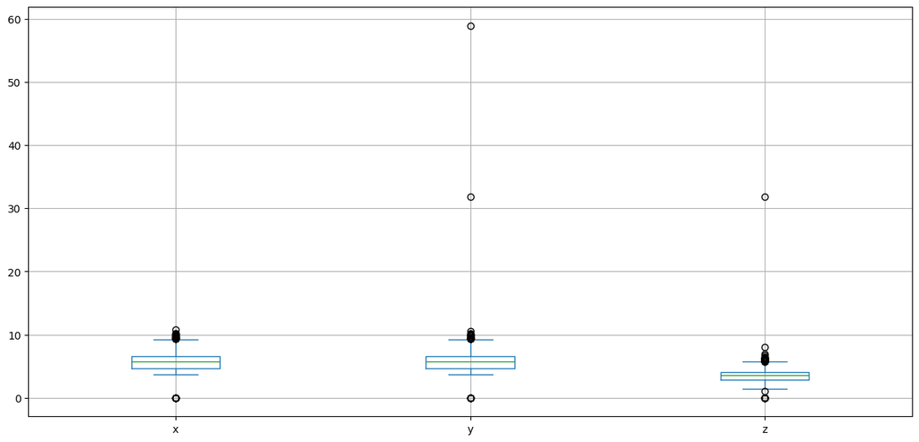

```python
# Your answer here
dfdi[["x", "y", "z"]].plot(kind="box", grid=True, figsize=(15,7))
```

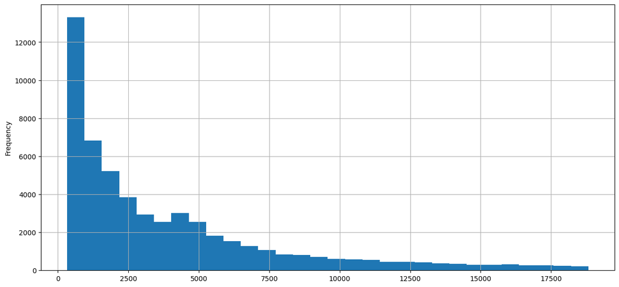

```python
# Your answer here
dfdi.price.plot(kind="hist", bins=30, grid=True, figsize=(15,7))
```

```
array([[<Axes: xlabel='carat', ylabel='carat'>,
        <Axes: xlabel='depth', ylabel='carat'>,
        <Axes: xlabel='table', ylabel='carat'>,
        <Axes: xlabel='price', ylabel='carat'>],
       [<Axes: xlabel='carat', ylabel='depth'>,
        <Axes: xlabel='depth', ylabel='depth'>,
        <Axes: xlabel='table', ylabel='depth'>,
        <Axes: xlabel='price', ylabel='depth'>],
       [<Axes: xlabel='carat', ylabel='table'>,
        <Axes: xlabel='depth', ylabel='table'>,
        <Axes: xlabel='table', ylabel='table'>,
        <Axes: xlabel='price', ylabel='table'>],
       [<Axes: xlabel='carat', ylabel='price'>,
        <Axes: xlabel='depth', ylabel='price'>,
        <Axes: xlabel='table', ylabel='price'>,
        <Axes: xlabel='price', ylabel='price'>]], dtype=object)
```

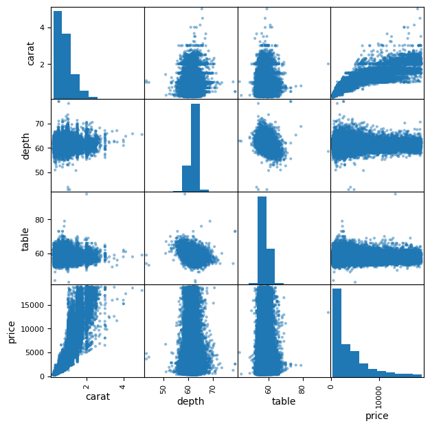

```python
# Your answer here
pd.plotting.scatter_matrix(dfdi[["carat", "depth", "table", "price"]], figsize=(7,7), diagonal="hist")
```

9. (0.5 pts) There are 7 unique colors in the `color` column of `dfdi`: *D*, *E*, *F*, *G*, *H*, *I*, and *J*. Plot a bar plot that displays the mean prices for the 7 colors. Set the `figsize` to 10 x 5. Use the **groupby** method to calculate the mean prices for the 7 colors.

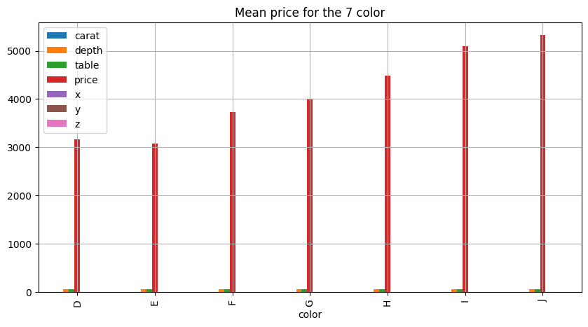

```python
# Your answer here
color = dfdi.groupby("color").mean()
color.plot(kind="bar", title="Mean price for the 7 color", grid=True, figsize=(10,5))
```

10. (0.5 pts) Plot an interactive plot in which a radio buttons widget (refer to the documentation below) allows users to select a cut type among *All*, *Fair*, *Good*, *Ideal*, *Premium*, and *Very Good*, and interactively displays the dataframe that contains the rows with the selected cut type. For example, if the user selects the *Premium* cut type, it displays the dataframe that contains the rows with the Premium cut. If the user selects *All*, it displays the entire dataframe with all rows. The default value for the widget is *All*. To display a dataframe `dftmp`, use **display(dftmp)**. Do not use the **print** function

RadioButtons Widget: https://ipywidgets.readthedocs.io/en/stable/examples/Widget%20List.html#RadioButtons

```python
# Your answer here
from ipywidgets import widgets, interactive, Layout
w_cuttype = widgets.RadioButtons(
    description = 'Cut type:',
    options =  ["All"] + sorted(set(dfdi.cut)),
    #['All', 'Fair', 'Good', 'Ideal', 'Preimum', 'Very Good'],
    style = {"description_width": '50px'},
    layout = Layout(width="70%"),
    disabled = False
)

def view(cut):
    if w_cuttype.value == "All":
        dftmp = dfdi
    else:
        dftmp = dfdi[dfdi.cut == w_cuttype.value]

    title = "Cut type for {}".format(w_cuttype.value)
    dftmp[["carat", "depth", "table", "price", "x", "y", "z"]].plot(kind="box", title=title, grid=True, figsize=(15,7))

i = interactive(view, cut=w_cuttype)     # The value of the widget is passed to the view function as a parameter value.
display(i)
```

```
interactive(children=(RadioButtons(description='Cut type:', layout=Layout(width='70%'), options=('All', 'Fair'…
```

### Now that you have completed all the questions, click Kernel > Restart & Run All to creat a clean version of this notebook and check if all cells have run as expected.